# R Notebook

# CHL5222 Final Project

# Breastfeeding and HIV exposure on infant growth

# Main outcome: weight-for-length z-score (zwfl)

# Secondary outcome: head circumference z-score (zhc)

```r
library(tidyverse)
library(lme4)
library(lmerTest)
library(naniar)
library(splines)
library(emmeans)
library(ggeffects)
library(broom.mixed)
library(patchwork)
library(janitor)
```

## Import data

```r
dat <- read.csv("hiv.csv", stringsAsFactors = FALSE) |>
  clean_names()
```

## Variable Descriptions

The dataset contains repeated growth measurements of infants followed from birth to 24 months to evaluate the relationship between HIV exposure, breastfeeding, and infant growth.

- `newid`  
  Unique identifier for each infant. Used to link repeated observations from the same child in longitudinal analysis.
- `visit`  
  Study visit number when the measurement was collected.
- `infage_month`  
  Infant age in months at the time of measurement. This variable represents the time dimension in the longitudinal analysis.
- `zwfl`  
  Weight-for-length z-score. This standardized measure compares an infant’s weight relative to their length based on WHO growth standards and is used as the primary growth outcome.
- `zhc`  
  Head circumference z-score. This standardized measure reflects head growth relative to age and is considered a secondary growth outcome.
- `enrol_hiv_status_cat`  
  Maternal HIV status at enrollment. This variable defines whether the infant was exposed to HIV during pregnancy (CHEU) or not exposed (CHU).
- `ebf_updated`  
  Exclusive breastfeeding status. Indicates whether the infant was exclusively breastfed.
- `bf_current_1year`  
  Current breastfeeding status. Indicates whether the infant is currently being breastfed at the time of observation.
- `b1_sex`  
  Infant sex.
- `gestage_final`  
  Gestational age at birth (in weeks). This variable accounts for differences in growth related to prematurity.
- `momage_cat`  
  Maternal age category at the time of delivery.
- `educ_cat_n`  
  Maternal education level. This variable represents socioeconomic and demographic characteristics that may influence infant growth.

## Inspect data

```r
str(dat)
```

```
'data.frame':   2934 obs. of  12 variables:
 $ newid               : int  96 96 96 96 96 96 96 96 96 97 ...
 $ visit               : chr  "delivery" "week-3" "week-6" "month-12" ...
 $ enrol_hiv_status_cat: chr  "Negative" "Negative" "Negative" "Negative" ...
 $ momage_cat          : chr  "26 to 35" "26 to 35" "26 to 35" "26 to 35" ...
 $ educ_cat_n          : chr  "Primary or below" "Primary or below" "Primary or below" "Primary or below" ...
 $ b1_sex              : chr  "female" "female" "female" "female" ...
 $ gestage_final       : num  38 38 38 38 38 ...
 $ ebf_updated         : chr  "yes" "yes" "yes" "yes" ...
 $ bf_current_1year    : chr  "y" "y" "y" "y" ...
 $ infage_month        : num  0.13 0.81 1.39 11.9 18.13 ...
 $ zwfl                : num  -0.68 -0.22 0.02 1.42 0.98 0.47 0.64 0.46 0.61 0.1 ...
 $ zhc                 : num  -0.22 1.88 2.04 0.5 0.79 0.51 1.58 1.11 0.81 2.9 ...
```

```r
summary(dat)
```

```
     newid          visit           enrol_hiv_status_cat  momage_cat
 Min.   : 96.0   Length:2934        Length:2934          Length:2934
 1st Qu.:179.0   Class :character   Class :character     Class :character
 Median :263.0   Mode  :character   Mode  :character     Mode  :character
 Mean   :262.2
 3rd Qu.:345.0
 Max.   :428.0

  educ_cat_n           b1_sex          gestage_final   ebf_updated
 Length:2934        Length:2934        Min.   :31.61   Length:2934
 Class :character   Class :character   1st Qu.:38.00   Class :character
 Mode  :character   Mode  :character   Median :39.00   Mode  :character
                                       Mean   :39.09
                                       3rd Qu.:40.00
                                       Max.   :48.48

 bf_current_1year    infage_month         zwfl              zhc
 Length:2934        Min.   : 0.000   Min.   :-5.5600   Min.   :-6.6400
 Class :character   1st Qu.: 1.370   1st Qu.:-0.5900   1st Qu.:-0.7125
 Mode  :character   Median : 6.000   Median : 0.1800   Median :-0.0200
                    Mean   : 8.262   Mean   : 0.1964   Mean   :-0.0423
                    3rd Qu.:12.030   3rd Qu.: 1.0100   3rd Qu.: 0.6325
                    Max.   :35.550   Max.   : 5.4800   Max.   : 4.3900
                                     NA's   :37        NA's   :2
```

```r
colSums(is.na(dat))
```

```
               newid                visit enrol_hiv_status_cat           momage_cat
                   0                    0                    0                    0
          educ_cat_n               b1_sex        gestage_final          ebf_updated
                   0                    0                    0                    5
    bf_current_1year         infage_month                 zwfl                  zhc
                  22                    0                   37                    2
```

## Recode variables

```r
analysis_dat <- dat |>
  mutate(
    newid = factor(newid),

    # HIV exposure group:
    # Assuming "Positive" = infant exposed to maternal HIV (CHEU)
    # and "Negative" = HIV-unexposed (CHU)
    hiv_group = case_when(
      enrol_hiv_status_cat == "Positive" ~ "CHEU",
      enrol_hiv_status_cat == "Negative" ~ "CHU",
      TRUE ~ NA_character_
    ),
    hiv_group = factor(hiv_group, levels = c("CHU", "CHEU")),

     # Order visits chronologically
    visit = factor(visit, levels = c(
      "delivery",
      "week-3",
      "week-6",
      "month-3",
      "month-6",
      "month-9",
      "month-12",
      "month-18",
      "month-24"
    )),

    # Sex
    sex = factor(b1_sex),

    # Maternal age category
    momage_cat = factor(momage_cat),

    # Maternal education
    educ_cat_n = factor(educ_cat_n),

    # Breastfeeding variables
    ebf_updated = case_when(
      tolower(ebf_updated) %in% c("yes", "y") ~ "Yes",
      tolower(ebf_updated) %in% c("no", "n")  ~ "No",
      TRUE ~ NA_character_
    ),
    ebf_updated = factor(ebf_updated, levels = c("No", "Yes")),

    bf_current_1year = case_when(
      tolower(bf_current_1year) %in% c("yes", "y") ~ "Yes",
      tolower(bf_current_1year) %in% c("no", "n")  ~ "No",
      TRUE ~ NA_character_
    ),
    bf_current_1year = factor(bf_current_1year, levels = c("No", "Yes")),

    # Continuous variables
    infage_month = as.numeric(infage_month),
    gestage_final = as.numeric(gestage_final),
    zwfl = as.numeric(zwfl),
    zhc  = as.numeric(zhc)
  )
```

## Basic checks

```r
# Number of infants and observations
analysis_dat |>
  summarise(
    n_obs = n(),
    n_infants = n_distinct(newid)
  )
```

| n_obs | n_infants |
| --- | --- |
| 2934 | 333 |

```r
# Outcome missingness
analysis_dat |>
  summarise(
    missing_zwfl = sum(is.na(zwfl)),
    missing_zhc  = sum(is.na(zhc))
  )
```

| missing_zwfl | missing_zhc |
| --- | --- |
| 37 | 2 |

```r
# Group counts
table(analysis_dat$hiv_group, useNA = "ifany")
```

```
 CHU CHEU
1431 1503
```

```r
table(analysis_dat$ebf_updated, useNA = "ifany")
```

```
  No  Yes <NA>
1301 1628    5
```

```r
table(analysis_dat$bf_current_1year, useNA = "ifany")
```

```
  No  Yes <NA>
 330 2582   22
```

## Exploratory plots

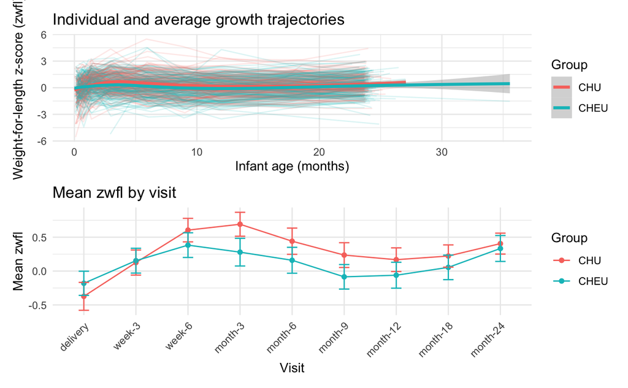

```r
# Spaghetti plot for zwfl
p1 <- analysis_dat |>
  filter(!is.na(zwfl), !is.na(hiv_group)) |>
  ggplot(aes(x = infage_month, y = zwfl, group = newid, color = hiv_group)) +
  geom_line(alpha = 0.15) +
  geom_smooth(aes(group = hiv_group), method = "loess", se = TRUE, linewidth = 1.2) +
  labs(
    title = "Individual and average growth trajectories",
    x = "Infant age (months)",
    y = "Weight-for-length z-score (zwfl)",
    color = "Group"
  ) +
  theme_minimal()

# Mean profile by visit
p2 <- analysis_dat |>
  filter(!is.na(zwfl), !is.na(hiv_group)) |>
  group_by(visit, hiv_group) |>
  summarise(
    mean_zwfl = mean(zwfl, na.rm = TRUE),
    se_zwfl = sd(zwfl, na.rm = TRUE) / sqrt(sum(!is.na(zwfl))),
    .groups = "drop"
  ) |>
  ggplot(aes(x = visit, y = mean_zwfl, group = hiv_group, color = hiv_group)) +
  geom_line() +
  geom_point() +
  geom_errorbar(aes(ymin = mean_zwfl - 1.96 * se_zwfl,
                    ymax = mean_zwfl + 1.96 * se_zwfl),
                width = 0.2) +
  labs(
    title = "Mean zwfl by visit",
    x = "Visit",
    y = "Mean zwfl",
    color = "Group"
  ) +
  theme_minimal() +
  theme(axis.text.x = element_text(angle = 45, hjust = 1))

p1 / p2
```

## Missingness

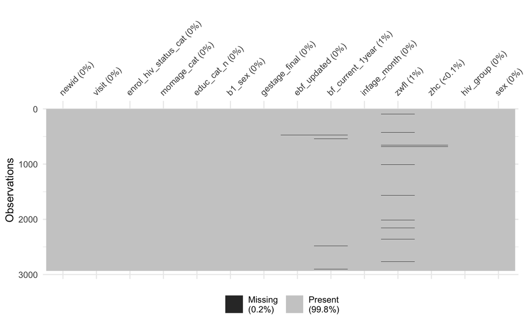

```r
vis_miss(analysis_dat)
```

## Main analysis dataset

```r
# Keep observations needed for main model
main_dat <- analysis_dat |>
  filter(
    !is.na(zwfl),
    !is.na(hiv_group),
    !is.na(infage_month),
    !is.na(bf_current_1year),
    !is.na(ebf_updated),
    !is.na(sex)
  ) |>
  mutate(
    infage_month_c = infage_month - mean(infage_month, na.rm = TRUE)
  )
```